# Possible extensions of the model

MtM ABM description

Author

David O’Sullivan

Published

February 19, 2025

This is a working ‘to do’ or ‘to consider’ list for ongoing work on the model. As suggestions come in from colleagues I’ll add them here appropriately parsed out as changes to the model.

### General issues

#### Model scales

The spatial and temporal scales of the model require clarification.

The notional time scale at present is one model time step per year. For a number of reasons it seems reasonable to change this to 5 years, with various model initialisation parameters changed accordingly.

The notional model geographical scale is one cell per hectare, although this seems likely to be a problem looking ahead. For example, the Rangitaiki catchment used to test the spatial data import aspects of the model occupies about 2900 km<sup>2</sup> or 290,000 ha. The current (arbitrary)rescaling of the spatial data applied to this region, given its spatial extent, reads the data in at a scale of around 16 ha to the grid cell.

Including 290,000 grid cells in the model will likely stretch its computational capacity. We should certainly consider a coarser resolution than 1 ha. per cell. It may make sense to work with 9, 16, or even 25 ha. cells.

Further, it’s worth noting that to accomodate the 290,000 ha. catchment, the axially NS-EW aligned model map area stretches to an area 120 by 62 km or 744,000 ha, meaning that over 60% of the map area is outside the catchment of interest.

Reorienting the input data to fit a ‘minimal oriented rectangle’ can improve this ratio so that a little under 50% of the 128 by 44 km (570,000 ha.) rectangular area is unused, but this is still not ideal. This approach would waste less model resources on land outside the catchment of interest, but 290,000 cells remains (almost certainly) too many regardless.

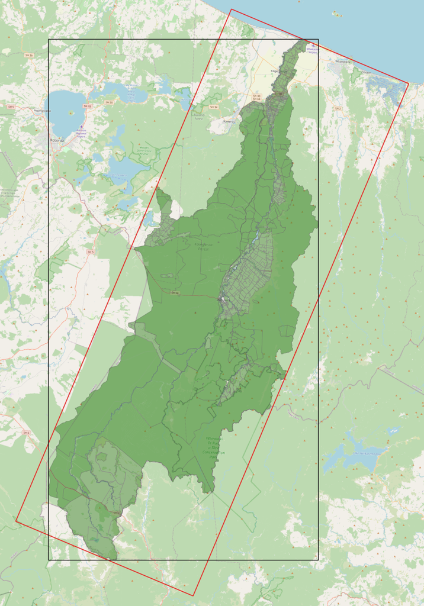

#### More data in GIS files

The current test data for parcels includes no information about actual land use. Including this either via a third layer from land cover data or perhaps via Agribase is desirable for realistic modelling of catchments in the real world.

It is unclear if parcels data gives us ‘holdings’ information or not. If holdings become mixed-LUC then while the calculation of incomes, yields, etc. will still work, some more consideration may have to be given to how holdings are prioritised for land use change and/or adoption of management interventions to reflect this greater complexity.

#### Farmer ages

The initial distribution of farmer ages has been ‘eyeballed’ to fit data from survey data. More precise fitting of the initial age distribution, the age distribution of new entrants, and the rater at which farmers exit by age may be considered desirable.

#### Output variables

Model does not currently have any specific set of output variables any set of experiments will necessarily require that some such be tracked. As Nathan notes (late Feb) these could include

> Environmental quality

> Financial condition of the average surviving farm business

> Numbers/proportions of financially viable farm businesses (maybe by farm type) in the average long-run steady state observed across 1000s of simulated runs.

Model infrastructure can be put in place to collect and analyse any or all of these once we settle on experiments. Proxies for all of these already exist, it’s just a matter of which to collate.

### Farmer decision making

#### Make farmer dispositions matter

Currently farmer dispositions (‘pro-social’, ‘pro-environmental’, ‘for-profit’) have no impact on the model. This can likely be incorporated by including additional cross-tabulations of the effect of different dispositions on the probability of taking up interventions or changing land use. Some additional model code would be required to make these changes.

#### Network effects

Code in the model allows for construction of ‘local networks’ and ‘industry networks’ in which farmers are connected to respectively near neighbours geographically or ‘peer’ farmers engaged in the same type of farming. These networks can be turned off, and currently have no effect on the model behaviour.

Activating the networks so that they impact model outcomes would not be difficult, although some thought is required to determine the extent of the networks For example:

- How many near neighbours from how far afield?
- How similar does another farm or farmer need to be to be considered a ‘peer’?
- Do farmer age and disposition feed into these choices?

It is important to recognise that every choice made in answering these questions implies a theory of behaviour, and that we may not have good data to support any specific choices.

#### Land use change decisions: potential impact of

In land use decision making, none of the following currently have an effect:

- Policy settings;
- The relative profitability of different land uses;
- Farmer dispositions; or
- The effect of recent changes on similar farms.

Policy settings and land use profitability can probably be folded into the conversion probabilities of a scenario. As noted in the previous two subsections, farmer dispositions and recent change on similar farms are present in the code, but inactive, so some code will need to be developed to include these effects.

#### Intervention adoption

Is it reasonable for the evaluation of interventions to be based on a difference between mean future profits and the most recent cost/income of a holding? This may make adoption of interventions more likely following a bad year! Some thought may be needed to clarify if this is in fact an effect (that interventions are more likely to be adopted in the model after bad years than good years), and if so if it should be changed, and how.

#### Different responsiveness to different kinds of factors

Currently only a single value of ‘responsiveness’ is allowed for when applying the sigmoid slope procedure to adjust the probability of uptake of interventions as a result of anticipated changes in income and costs. This is where we expect the effect of ‘nudges’ to be included in the model. It seems likely that we may want to allow for different kinds of nudges with differing levels of efficacy so that we might need to add additional model parameters. How these ‘responsiveness’ parameters should be calibrated and incorporated into scenario setups remains to be decided.

### Land market effects

There is no current provision in the model for land changing hands or for farms being amalgamated. This idea is mentioned in Nathan’s notes and might be of interest, but would likely involve some fairly substantial changes.

### Policy environment effects

Similarly these suggestions from Nathan would imply some substantial changes to the model to incorporate assumptions about the regulatory environment and long-term profitability into the farmer decision making process.

**Update History**

| Date | Changes |
| --- | --- |
| 2025-02-19 | Initial post. |